# Discriminant_analysis

# Logistic Regression

### 1. First, let’s do the pre-processing steps you were asked to do during the last session and fit a logistic regression model.

```r
dataset <- read.csv('http://www.mghassany.com/MLcourse/datasets/Social_Network_Ads.csv')

str(dataset)
```

```
'data.frame':   400 obs. of  5 variables:
 $ User.ID        : int  15624510 15810944 15668575 15603246 15804002 15728773 15598044 15694829 15600575 15727311 ...
 $ Gender         : chr  "Male" "Male" "Female" "Female" ...
 $ Age            : num  19 35 26 27 19 27 27 32 25 35 ...
 $ EstimatedSalary: num  19000 20000 43000 57000 76000 58000 84000 150000 33000 65000 ...
 $ Purchased      : int  0 0 0 0 0 0 0 1 0 0 ...
```

```r
summary(dataset)
```

```
    User.ID            Gender               Age        EstimatedSalary    Purchased
 Min.   :15566689   Length:400         Min.   :18.00   Min.   : 15000   Min.   :0.0000
 1st Qu.:15626764   Class :character   1st Qu.:29.75   1st Qu.: 43000   1st Qu.:0.0000
 Median :15694342   Mode  :character   Median :37.00   Median : 70000   Median :0.0000
 Mean   :15691540                      Mean   :37.66   Mean   : 69743   Mean   :0.3575
 3rd Qu.:15750363                      3rd Qu.:46.00   3rd Qu.: 88000   3rd Qu.:1.0000
 Max.   :15815236                      Max.   :60.00   Max.   :150000   Max.   :1.0000
```

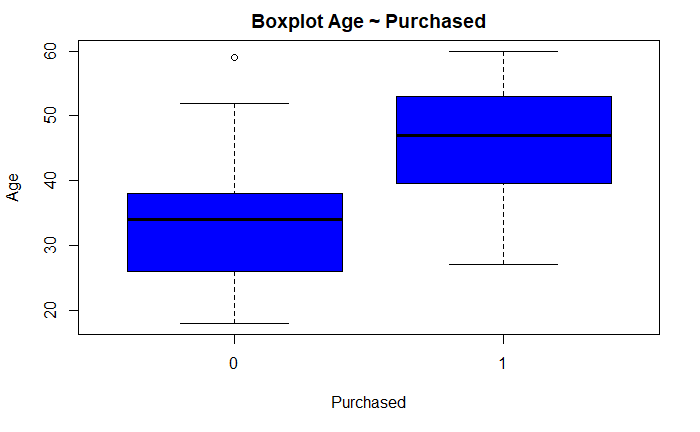

```r
boxplot(Age ~ Purchased, data=dataset, col = "blue", main="Boxplot Age ~ Purchased")
```

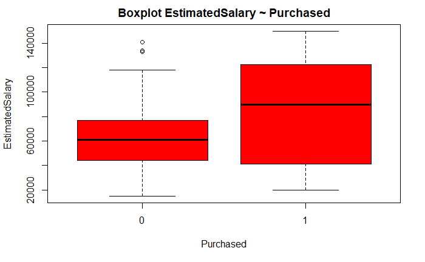

```r
boxplot(EstimatedSalary ~ Purchased, data=dataset,col = "red",
 main="Boxplot EstimatedSalary ~ Purchased")
```

```r
aov(EstimatedSalary ~Purchased, data=dataset)
```

```
Call:
   aov(formula = EstimatedSalary ~ Purchased, data = dataset)

Terms:
                   Purchased    Residuals
Sum of Squares   60816378455 403062099045
Deg. of Freedom            1          398

Residual standard error: 31823.24
Estimated effects may be unbalanced
```

```r
summary(aov(EstimatedSalary ~Purchased, data=dataset))
```

```
             Df    Sum Sq   Mean Sq F value   Pr(>F)
Purchased     1 6.082e+10 6.082e+10   60.05 7.77e-14 ***
Residuals   398 4.031e+11 1.013e+09
---
Signif. codes:  0 ‘***’ 0.001 ‘**’ 0.01 ‘*’ 0.05 ‘.’ 0.1 ‘ ’ 1
```

```r
summary(aov(Age ~Purchased, data=dataset))
```

```
             Df Sum Sq Mean Sq F value Pr(>F)
Purchased     1  16988   16988   251.7 <2e-16 ***
Residuals   398  26858      67
---
Signif. codes:  0 ‘***’ 0.001 ‘**’ 0.01 ‘*’ 0.05 ‘.’ 0.1 ‘ ’ 1
```

```r
table(dataset$Gender,dataset$Purchased)
```

```
           0   1
  Female 127  77
  Male   130  66
```

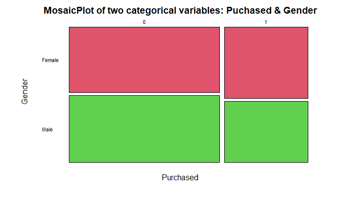

```r
mosaicplot(~ Purchased + Gender, data=dataset,
  main = "MosaicPlot of two categorical variables: Puchased & Gender",
  color = 2:3, las = 1)
```

```r
chisq.test(dataset$Purchased, dataset$Gender)
```

```
    Pearson's Chi-squared test with Yates' continuity correction

data:  dataset$Purchased and dataset$Gender
X-squared = 0.55509, df = 1, p-value = 0.4562
```

```r
dataset = dataset[3:5]
str(dataset)
```

```
'data.frame':   400 obs. of  3 variables:
 $ Age            : num  19 35 26 27 19 27 27 32 25 35 ...
 $ EstimatedSalary: num  19000 20000 43000 57000 76000 58000 84000 150000 33000 65000 ...
 $ Purchased      : int  0 0 0 0 0 0 0 1 0 0 ...
```

```r
library(caTools)
set.seed(123) # CHANGE THE VALUE OF SEED. PUT YOUR STUDENT'S NUMBER INSTEAD OF 123.
split = sample.split(dataset$Purchased, SplitRatio = 0.75)
training_set = subset(dataset, split == TRUE)
test_set = subset(dataset, split == FALSE)

training_set[-3] <- scale(training_set[-3]) #only first two columns
test_set[-3] <- scale(test_set[-3])



classifier.logreg <- glm(Purchased ~ Age + EstimatedSalary , family = binomial, data=training_set)
classifier.logreg
```

```
Call:  glm(formula = Purchased ~ Age + EstimatedSalary, family = binomial,
    data = training_set)

Coefficients:
    (Intercept)              Age  EstimatedSalary
         -1.192            2.632            1.395

Degrees of Freedom: 299 Total (i.e. Null);  297 Residual
Null Deviance:      390.9
Residual Deviance: 199.8    AIC: 205.8
```

```r
summary(classifier.logreg)
```

```
Call:
glm(formula = Purchased ~ Age + EstimatedSalary, family = binomial,
    data = training_set)

Deviance Residuals:
    Min       1Q   Median       3Q      Max
-3.0753  -0.5235  -0.1161   0.3224   2.3977

Coefficients:
                Estimate Std. Error z value Pr(>|z|)
(Intercept)      -1.1923     0.2018  -5.908 3.47e-09 ***
Age               2.6324     0.3461   7.606 2.83e-14 ***
EstimatedSalary   1.3947     0.2326   5.996 2.03e-09 ***
---
Signif. codes:  0 ‘***’ 0.001 ‘**’ 0.01 ‘*’ 0.05 ‘.’ 0.1 ‘ ’ 1

(Dispersion parameter for binomial family taken to be 1)

    Null deviance: 390.89  on 299  degrees of freedom
Residual deviance: 199.78  on 297  degrees of freedom
AIC: 205.78

Number of Fisher Scoring iterations: 6
```

```r
pred.glm = predict(classifier.logreg, newdata = test_set[,-3], type="response")

pred.glm_0_1 = ifelse(pred.glm >= 0.5, 1,0)

head(pred.glm)
```

```
          2           4           5           9          12          18
0.016239538 0.011714838 0.003784646 0.002452746 0.007333944 0.206157658
```

```r
head(pred.glm_0_1)
```

```
 2  4  5  9 12 18
 0  0  0  0  0  0
```

```r
cm = table(test_set[,3], pred.glm_0_1)
cm
```

```
   pred.glm_0_1
     0  1
  0 57  7
  1 10 26
```

```r
cm = table(pred.glm_0_1, test_set[,3])
cm
```

```
pred.glm_0_1  0  1
           0 57 10
           1  7 26
```

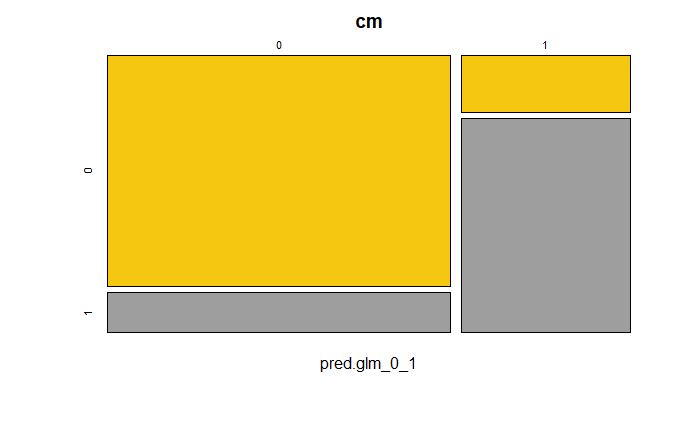

```r
mosaicplot(cm,col=sample(1:8,2)) # colors are random between 8 colors.
```

```r
require(ROCR)
score <- prediction(pred.glm,test_set[,3])
performance(score,"auc") # y.values
```

```
A performance instance
  'Area under the ROC curve'
```

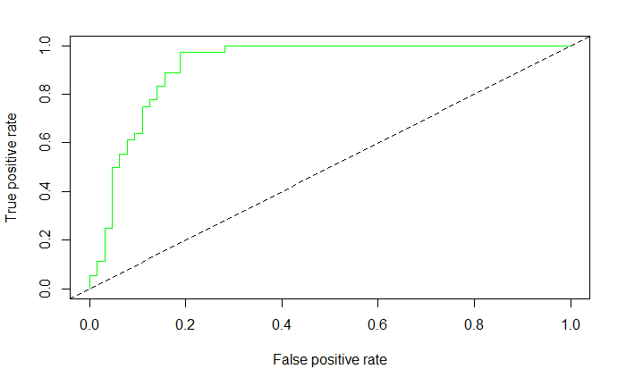

```r
plot(performance(score,"tpr","fpr"),col="green")
abline(0,1,lty=8)
```

# Decision Boundary of Logistic Regression

### 2. Plot the decision boundary obtained with logistic regression.

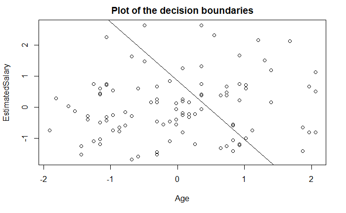

```r
slope_boundary = -classifier.logreg$coefficients[2]/classifier.logreg$coefficients[3]
intercept_boundary = -classifier.logreg$coefficients[1]/classifier.logreg$coefficients[3]

plot(test_set$Age, test_set$EstimatedSalary, main="Plot of the decision boundaries", xlab="Age",ylab="EstimatedSalary")
abline(intercept_boundary, slope_boundary)
```

### 3. In order to verify that your line (decision boundary) is well plotted, color the points on the last Figure with respect to the predicted response.

```r
plot(test_set$Age,test_set$EstimatedSalary, xlab = 'Age', ylab = 'EstimatedSalary', main="Decision Boundary for the Logistic Regression")
points(test_set[c(1,2)], pch = 21, bg = ifelse(pred.glm_0_1 == 1, 'green', 'red'))
```

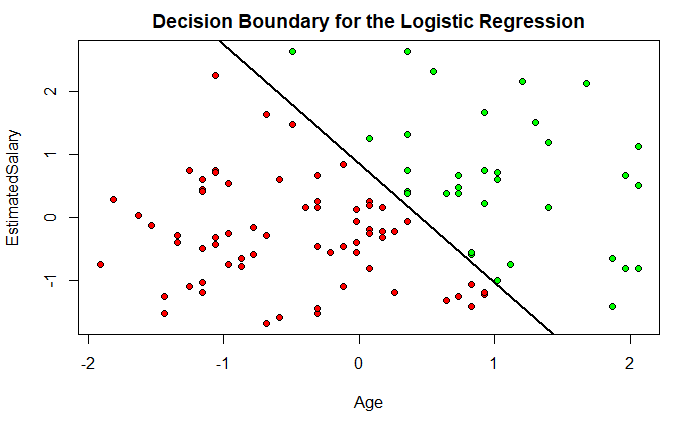

```r
abline(intercept_boundary,slope_boundary, lw=2)
```

### 4. Now make the same plot but color the points with respect to their real labels (the variable Purchased). From this figure, count the number of the false positive predictions and compare it to the value obtained in the confusion matrix.

```r
plot(test_set$Age,test_set$EstimatedSalary, xlab = 'Age', ylab = 'EstimatedSalary', main="Decision Boundary Logistic Regression")
points(test_set[c(1,2)], pch = 21, bg = ifelse(test_set["Purchased"] == 1, 'green4', 'red3'))
```

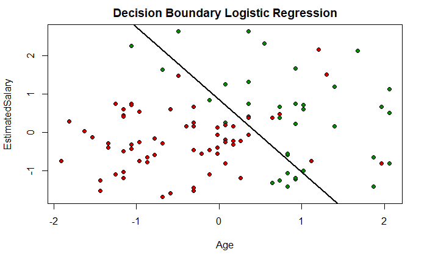

```r
abline(intercept_boundary,slope_boundary, lw=2)
```

# Linear Discriminant Analysis (LDA)

### 5. Fit a LDA model of Purchased in function of Age and EstimatedSalary. Name the model classifier.lda.

```r
library(MASS)
classifier.lda <- lda(Purchased~Age+EstimatedSalary, data=training_set)
```

### 6. Call classifier.lda and understand what does it compute.

```r
classifier.lda$prior
```

```
        0         1
0.6433333 0.3566667
```

```r
classifier.lda$means
```

```
         Age EstimatedSalary
0 -0.4617220      -0.2827853
1  0.8328257       0.5100707
```

### 7. On the test set, predict the probability of purchasing the product by the users using the model classifier.lda. Remark that when we predict using LDA, we obtain a list instead of a matrix, do str() for your predictions to see what do you get.

```r
# We don't need to put the parameter type = "response" because we get the prediction equal to 1 or 0 directly with this model
pred.lda = predict(classifier.lda, newdata = test_set[c("Age", "EstimatedSalary")])
str(pred.lda)
```

```
List of 3
 $ class    : Factor w/ 2 levels "0","1": 1 1 1 1 1 1 1 1 2 1 ...
 $ posterior: num [1:100, 1:2] 0.971 0.979 0.992 0.994 0.986 ...
  ..- attr(*, "dimnames")=List of 2
  .. ..$ : chr [1:100] "2" "4" "5" "9" ...
  .. ..$ : chr [1:2] "0" "1"
 $ x        : num [1:100, 1] -1.22 -1.41 -1.92 -2.07 -1.61 ...
  ..- attr(*, "dimnames")=List of 2
  .. ..$ : chr [1:100] "2" "4" "5" "9" ...
  .. ..$ : chr "LD1"
```

### 8. Compute the confusion matrix and compare the predictions results obtained by LDA to the ones obtained by logistic regression. What do you remark?

```r
# We can see with the previous question that the class predictions are located in pred.lda$class so:
cm.lda = table(test_set$Purchased, pred.lda$class)
cm.lda
```

```
     0  1
  0 57  7
  1 10 26
```

```r
cm
```

```
pred.glm_0_1  0  1
           0 57 10
           1  7 26
```

```r
# create a grid corresponding to the scales of Age and EstimatedSalary
# and fill this grid with lot of points
X1 = seq(min(training_set[, 1]) - 1, max(training_set[, 1]) + 1, by = 0.01)
X2 = seq(min(training_set[, 2]) - 1, max(training_set[, 2]) + 1, by = 0.01)
grid_set = expand.grid(X1, X2)
# Adapt the variable names
colnames(grid_set) = c('Age', 'EstimatedSalary')

# plot 'Estimated Salary' ~ 'Age'
plot(test_set[, 1:2],
     main = 'Decision Boundary LDA',
     xlab = 'Age', ylab = 'Estimated Salary',
     xlim = range(X1), ylim = range(X2))

# color the plotted points with their real label (class)
points(test_set[1:2], pch = 21, bg = ifelse(test_set[, 3] == 1, 'green4', 'red3'))
```

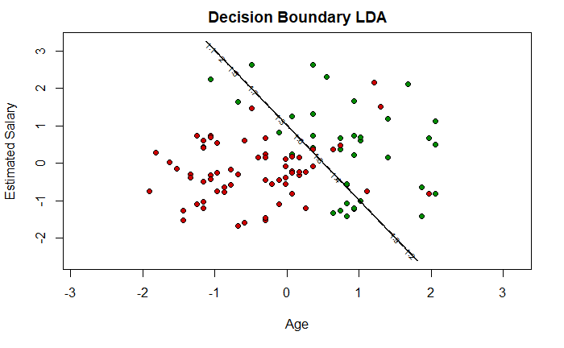

```r
# Make predictions on the points of the grid, this will take some time
pred_grid = predict(classifier.lda, newdata = grid_set)$class

# Separate the predictions by a contour
contour(X1, X2, matrix(as.numeric(pred_grid), length(X1), length(X2)), add = TRUE)
```

# LDA from scratch

### 10. Now let us build a LDA model for our data set without using the lda() function. You are free to do it by creating a function or without creating one. Go back to question 6 and see what did you obtain by using lda(). It computes the prior probability of group membership and the estimated group means for each of the two groups. Additional information that is not provided, but may be important, is the single covariance matrix that is being used for the various groupings.

### 10.1 Subset the training set into two sets: class0 where Purchased = 0 and class1 where Purchased = 1).

```r
class0 = training_set[which(training_set$Purchased==0),]
class1 = training_set[which(training_set$Purchased==1),]
```

### 10.2 Compute π0 and π1.

```r
pi0=nrow(class0)/nrow(training_set)
pi1=nrow(class1)/nrow(training_set)
pi0
```

```
[1] 0.6433333
```

```r
pi1
```

```
[1] 0.3566667
```

```r
classifier.lda$prior
```

```
        0         1
0.6433333 0.3566667
```

### 10.3 Compute μ0 and μ1 .

```r
mu0=c(mean(class0$Age),mean(class0$EstimatedSalary))
mu1=c(mean(class1$Age),mean(class1$EstimatedSalary))
mu0
```

```
[1] -0.4617220 -0.2827853
```

```r
mu1
```

```
[1] 0.8328257 0.5100707
```

```r
classifier.lda$means
```

```
         Age EstimatedSalary
0 -0.4617220      -0.2827853
1  0.8328257       0.5100707
```

### 10.4 Compute Σ. In the case of two classes like here, it is computed by calculating the following:

```r
sigma=((nrow(class0)-1)*cov(class0[-3])+(nrow(class1)-1)*cov(class1[-3]))/(nrow(class0)+nrow(class1)-2)
sigma
```

```
                        Age EstimatedSalary
Age              0.61624102     -0.07456509
EstimatedSalary -0.07456509      0.85814717
```

### 10.5 Now that we have computed all the needed estimates, we can calculate δ0(x) and δ1(x) for any observation x. And we will attribute x to the class with the highest δ. First, try it for x where xT = (1,1.5), what is class prediction for this specific x ?

```r
x=c(1,1.5)
sigma.inv = solve(sigma)
# We use t() function to transpose the vector x and %*% for the dot product
delta0=(t(x)%*%sigma.inv%*%mu0) - (0.5*t(mu0)%*%sigma.inv%*%mu0) + log(pi0)
delta1=(t(x)%*%sigma.inv%*%mu1) - (0.5*t(mu1)%*%sigma.inv%*%mu1) + log(pi1)

ifelse(delta0>=delta1,0,1)
```

```
     [,1]
[1,]    1
```

The class prediction for this specific x is 1 (True) so this user purchased the product

### 10.6. Compute the discriminant scores δ for the test set (a matrix 100 ×2), predict the classes and compare your results with the results obtained with the lda() function.

```r
delta0 = numeric()
delta1 = numeric()
classes= numeric()

for(i in 1:nrow(test_set)){
delta0[i] = as.matrix(test_set[i,c("Age", "EstimatedSalary")])%*%sigma.inv%*%mu0 - 0.5 * t(mu0)%*%sigma.inv%*%mu0 + log(pi0)

delta1[i] = as.matrix(test_set[i,c("Age", "EstimatedSalary")])%*%sigma.inv%*%mu1 - 0.5 * t(mu1)%*%sigma.inv%*%mu1 + log(pi1)
}

for(i in 1:length(delta0)){
  classes[i] = ifelse(delta0[i]>=delta1[i],0,1)
}

y_pred = predict(classifier.lda, newdata = test_set[-3])

sum(classes == as.vector(y_pred$class))
```

```
[1] 100
```

# Quadratic Discriminant Analysis (QDA)

### 11. Fit a QDA model of Purchased in function of Age and EstimatedSalary. Name the model classifier.qda.

```r
classifier.qda <- qda(Purchased~Age+EstimatedSalary, data=training_set)
```

### 12. Make predictions on the test_set using the QDA model classifier.qda. Show the confusion matrix and compare the results with the predictions obtained using the LDA model classifier.lda.

```r
pred.qda = predict(classifier.qda, newdata = test_set[c("Age", "EstimatedSalary")])
str(pred.lda)
```

```
List of 3
 $ class    : Factor w/ 2 levels "0","1": 1 1 1 1 1 1 1 1 2 1 ...
 $ posterior: num [1:100, 1:2] 0.971 0.979 0.992 0.994 0.986 ...
  ..- attr(*, "dimnames")=List of 2
  .. ..$ : chr [1:100] "2" "4" "5" "9" ...
  .. ..$ : chr [1:2] "0" "1"
 $ x        : num [1:100, 1] -1.22 -1.41 -1.92 -2.07 -1.61 ...
  ..- attr(*, "dimnames")=List of 2
  .. ..$ : chr [1:100] "2" "4" "5" "9" ...
  .. ..$ : chr "LD1"
```

So we use pred.qda$class to get the class predictions like with the lda model

```r
cm.qda = table(test_set$Purchased, pred.qda$class)
cm.qda
```

```
     0  1
  0 57  7
  1  4 32
```

```r
cm.lda
```

```
     0  1
  0 57  7
  1 10 26
```

Here, we can see that the qda model has less false negative than the qda model. qda is a better model than lda

```r
classifier.qda
```

```
Call:
qda(Purchased ~ Age + EstimatedSalary, data = training_set)

Prior probabilities of groups:
        0         1
0.6433333 0.3566667

Group means:
         Age EstimatedSalary
0 -0.4617220      -0.2827853
1  0.8328257       0.5100707
```

### 13. Plot the decision boundary obtained with QDA. Color the points with the real labels.

Here the decision boundary is a curve

```r
# create a grid corresponding to the scales of Age and EstimatedSalary
# and fill this grid with lot of points
X1 = seq(min(training_set[, 1]) - 1, max(training_set[, 1]) + 1, by = 0.01)
X2 = seq(min(training_set[, 2]) - 1, max(training_set[, 2]) + 1, by = 0.01)
grid_set = expand.grid(X1, X2)
# Adapt the variable names
colnames(grid_set) = c('Age', 'EstimatedSalary')

# plot 'Estimated Salary' ~ 'Age'
plot(test_set[, 1:2],
     main = 'Decision Boundary QDA',
     xlab = 'Age', ylab = 'Estimated Salary',
     xlim = range(X1), ylim = range(X2))

# color the plotted points with their real label (class)
points(test_set[1:2], pch = 21, bg = ifelse(test_set[, 3] == 1, 'green4', 'red3'))
```

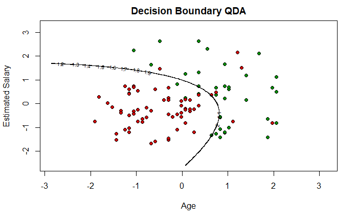

```r
# Make predictions on the points of the grid, this will take some time
pred_grid = predict(classifier.qda, newdata = grid_set)$class

# Separate the predictions by a contour
contour(X1, X2, matrix(as.numeric(pred_grid), length(X1), length(X2)), add = TRUE)
```

# Comparison

### 14. In order to compare the methods we used, plot on the same Figure the ROC curve for each classifier we fitted and compare the correspondant AUC. What was the best model for this dataset? Can you justify it?

We need the proba for each class for the lda and qda models so we used the $posterior matrix.  
Here, we want the proba of purchased (1) so we choose the second column of the matrix

```r
pred.lda$posterior
```

```
              0           1
2   0.970814501 0.029185499
4   0.979463765 0.020536235
5   0.992399883 0.007600117
9   0.994232201 0.005767799
12  0.986015397 0.013984603
18  0.764320839 0.235679161
19  0.709594424 0.290405576
20  0.607069919 0.392930081
22  0.481903797 0.518096203
29  0.981023764 0.018976236
32  0.729119564 0.270880436
34  0.984026329 0.015973671
35  0.935777224 0.064222776
38  0.971211698 0.028788302
```

[output cut: 86 more lines]

```r
library(ROCR)

score.glm = prediction(pred.glm,test_set$Purchased)
score.lda = prediction(pred.lda$posterior[,2],test_set$Purchased)
score.qda = prediction(pred.qda$posterior[,2],test_set$Purchased)

perf_tpr_fpr.glm = performance(score.glm,"tpr","fpr")
perf_tpr_fpr.lda = performance(score.lda,"tpr","fpr")
perf_tpr_fpr.qda = performance(score.qda,"tpr","fpr")

plot(perf_tpr_fpr.glm, col="red", main="ROC curves for the glm, lda and qda models")
plot(perf_tpr_fpr.lda, col="blue", add=TRUE)
```

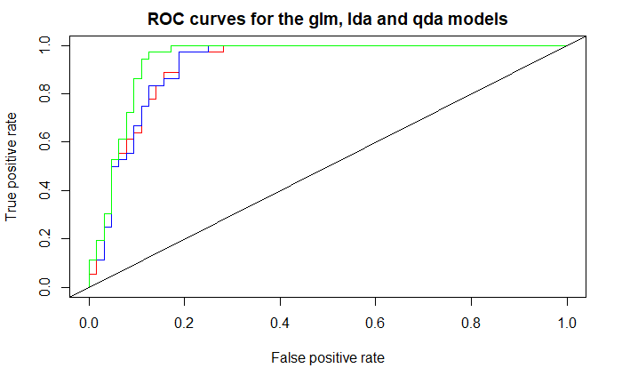

```r
plot(perf_tpr_fpr.qda, col="green", add=TRUE)
abline(0,1)
```

```r
# Let's compute also the AUC score
perf_auc.glm = performance(score.glm,"auc")
perf_auc.lda = performance(score.lda,"auc")
perf_auc.qda = performance(score.qda,"auc")

auc.glm = perf_auc.glm@y.values[[1]]
auc.glm
```

```
[1] 0.9171007
```

```r
auc.lda = perf_auc.lda@y.values[[1]]
auc.lda
```

```
[1] 0.9179688
```

```r
auc.qda = perf_auc.qda@y.values[[1]]
auc.qda
```

```
[1] 0.9405382
```

We can say that the best model for this dataset was the Quadratic Discriminant Analysis because it has the best auc values and its ROC curve is the closest to the bend of the ideal classifier which goes from (0,0) to (0,1) to (1,1).